# Lab 06 - Professor attractiveness and course evaluations, Part 1

### Part 2: Linear regression with a numerical predictor

```r
m_bty <- lm(score ~ bty_avg, data = evals)
```

```r
tidy(m_bty)
```

```
## # A tibble: 2 × 5
##   term        estimate std.error statistic   p.value
##   <chr>          <dbl>     <dbl>     <dbl>     <dbl>
## 1 (Intercept)   3.88      0.0761     51.0  1.56e-191
## 2 bty_avg       0.0666    0.0163      4.09 5.08e-  5
```

$\hat{score} = 3.880 + 0.0666(btyavg)$

5. Replot your visualization from Exercise 3, and add the regression line to this plot in orange color. Turn off the shading for the uncertainty of the line. Hint: use `se = FALSE` and `col = "orange"` in your `geom_smooth()` function call.

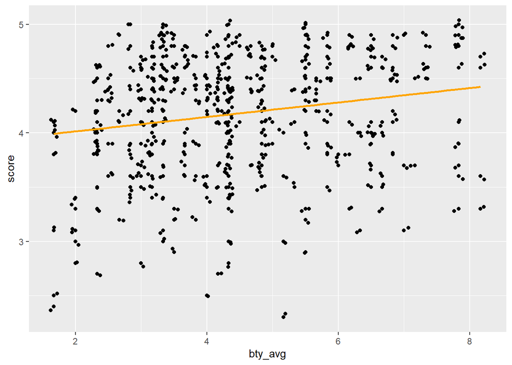

```r
ggplot(evals, aes(x = bty_avg, y = score)) +
  geom_point() +
  geom_jitter() +
  geom_smooth(method = "lm", se = FALSE, col = "orange")
```

6. Interpret the slope of the linear model in context of the data. For each unit of increase in a professor’s average beauty score, we expect to see about a 0.0666 increase in overall score of the course.

7. Interpret the intercept of the linear model in context of the data. Comment on whether or not the intercept makes sense in this context. When a professor’s beauty average is 0, we expect the overall course to have a score of 3.880. It does makes sense because this intercept value is somewhat close to the minimum value of score in our dataset, which is about 2.3.
8. Determine the $R^2$ of the model and interpret it in context of the data. The $R^2$ of the model is 0.03502. This means that about 3.502% of the variation in score for a class can be explained by the linear relationship with the average beauty rating of a professor. Therefore, about 96% of the variation in the score for a class is determined by other variables.

```r
summary(m_bty)
```

```
##
## Call:
## lm(formula = score ~ bty_avg, data = evals)
##
## Residuals:
##     Min      1Q  Median      3Q     Max
## -1.9246 -0.3690  0.1420  0.3977  0.9309
##
## Coefficients:
##             Estimate Std. Error t value Pr(>|t|)
## (Intercept)  3.88034    0.07614   50.96  < 2e-16 ***
## bty_avg      0.06664    0.01629    4.09 5.08e-05 ***
## ---
## Signif. codes:  0 '***' 0.001 '**' 0.01 '*' 0.05 '.' 0.1 ' ' 1
##
## Residual standard error: 0.5348 on 461 degrees of freedom
## Multiple R-squared:  0.03502,    Adjusted R-squared:  0.03293
## F-statistic: 16.73 on 1 and 461 DF,  p-value: 5.083e-05
```

9. Create a residual plot for your model and discuss what the plot tells you. Use the `augment()` function to add `.fitted` and `.resid` columns to your model output `m_bty`. Then use `ggplot()` to create a scatterplot of the fitted values versus the residuals. Use `geom_hline(yintercept = 0, color = "blue", lty = 2)` to add a horizontal reference line at `y=0`.

```r
m_bty_aug <- augment(m_bty)
```

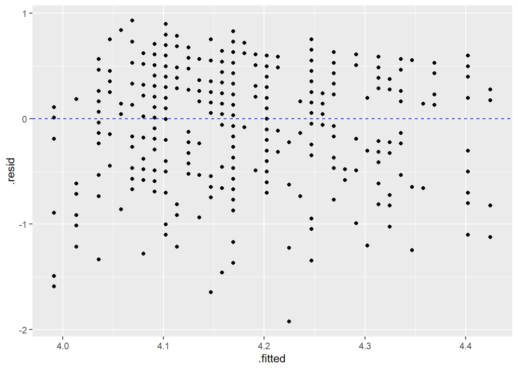

```r
ggplot(data = m_bty_aug, aes(x = .fitted, y = .resid)) +
    geom_point() +
    geom_hline(yintercept = 0, color = "blue", lty = 2)
```

The residual plot has no clear pattern, therefore this linear model is usable for inference. There are no regression model assumption violated when there is a random pattern such as in this plot.

10. Inspect the distribution of the residuals by first constructing a histogram and then constructing a normal probability plot. What can you conclude from these plots?

[figure not shown]

```r
ggplot(data = evals, aes(x= bty_avg)) +
  geom_histogram(fill = "cadetblue", color = "white", binwidth = .5)
```

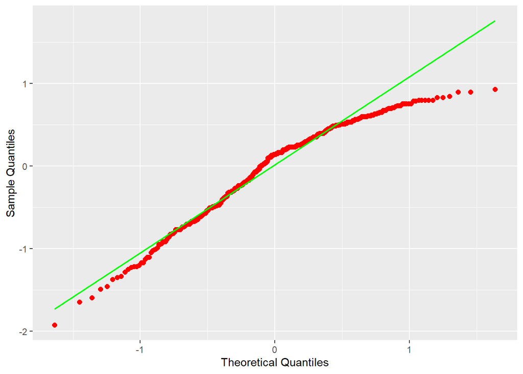

```r
ggplot(m_bty_aug, aes(sample = .resid)) +
  stat_qq_point(size = 2, color = "red") +
  stat_qq_line(color = "green") +
  xlab("Theoretical Quantiles") + ylab("Sample Quantiles")
```

```r
shapiro.test(m_bty_aug$.resid)
```

```
##
##  Shapiro-Wilk normality test
##
## data:  m_bty_aug$.resid
## W = 0.95491, p-value = 1.089e-10
```

11. Use `tidy(m_bty)` to examine the output for your model `m_bty`. What does the p-value for the slope tell us? Use the `confint` function to get a 95% confidence interval for the true slope $\beta_1$. Does your confidence interval confirm what you found for the p-value? Explain.

```r
tidy(m_bty)
```

```
## # A tibble: 2 × 5
##   term        estimate std.error statistic   p.value
##   <chr>          <dbl>     <dbl>     <dbl>     <dbl>
## 1 (Intercept)   3.88      0.0761     51.0  1.56e-191
## 2 bty_avg       0.0666    0.0163      4.09 5.08e-  5
```

```r
confint(m_bty)
```

```
##                  2.5 %     97.5 %
## (Intercept) 3.73070764 4.02996827
## bty_avg     0.03462292 0.09865116
```

The p-value for the slope is 5.082731e-05 which is really close to 0 meaning that there is an association between average beauty score and course score. The null hypothesis for slope is that the slope is equal to zero meaning that there is not an association between the two variables. However, the confidence interval for the slope of this model reveals that we are 95% confident that the true slope for this model is between 0.0346 and 0.0987. This interval does not contain zero, and thus, the null hypothesis is rejected in favor of there being an association between the two variables.

### Part 3: Linear regression with a categorical predictor

12. Visualize and describe the relationship between the average professor evaluation `score` and `gender`. What can you conclude from your visualization? Does there appear to be an association between these two variables?

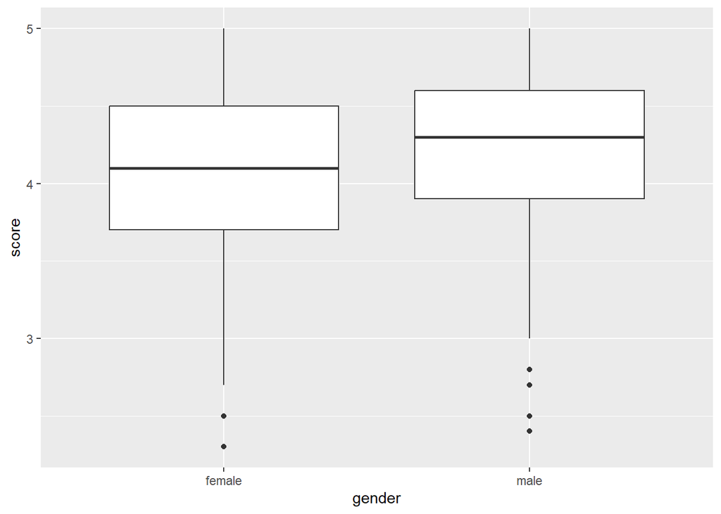

```r
ggplot(evals, aes(x = gender, y = score)) +
  #geom_jitter() +
  geom_boxplot()
```

The boxplots for the two variables are different from each other, suggesting there is an association between gender and score.

13. Fit a new linear model called `m_gen` to predict average professor evaluation `score` based on `gender` of the professor. Using the regression output, write the linear model and interpret the slope and intercept in context of the data. Use the `tidy()` function to view the model parameter estimates.

$\hat{score} = 4.093 + 0.141(gender)$

```r
m_gen <- lm(score ~ gender, data = evals)
```

```r
m_gen_aug <- augment(m_gen)
tidy(m_gen)
```

```
## # A tibble: 2 × 5
##   term        estimate std.error statistic p.value
##   <chr>          <dbl>     <dbl>     <dbl>   <dbl>
## 1 (Intercept)    4.09     0.0387    106.   0
## 2 gendermale     0.142    0.0508      2.78 0.00558
```

```r
summary(m_gen)
```

```
##
## Call:
## lm(formula = score ~ gender, data = evals)
##
## Residuals:
##      Min       1Q   Median       3Q      Max
## -1.83433 -0.36357  0.06567  0.40718  0.90718
##
## Coefficients:
##             Estimate Std. Error t value Pr(>|t|)
## (Intercept)  4.09282    0.03867 105.852  < 2e-16 ***
## gendermale   0.14151    0.05082   2.784  0.00558 **
## ---
## Signif. codes:  0 '***' 0.001 '**' 0.01 '*' 0.05 '.' 0.1 ' ' 1
##
## Residual standard error: 0.5399 on 461 degrees of freedom
## Multiple R-squared:  0.01654,    Adjusted R-squared:  0.01441
## F-statistic: 7.753 on 1 and 461 DF,  p-value: 0.005583
```

14. Create a residual plot for your model and discuss what the plot tells you.

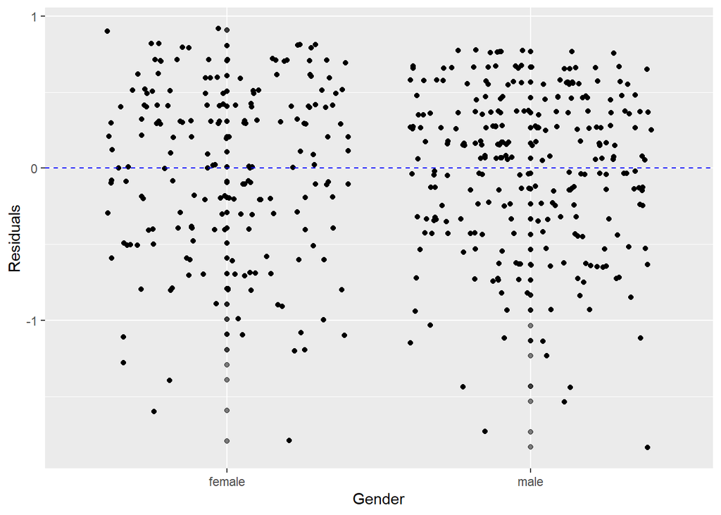

```r
ggplot(data = m_gen_aug, mapping = aes(x = gender, y = .resid)) +
  geom_point(alpha = 0.5) +
  geom_jitter() +
  geom_hline(yintercept = 0, color = "blue", lty = 2) +
  labs(x = "Gender", y = "Residuals")
```

This residual plot almost has a strange pattern with how there appear to be two rectangles but I think this is mainly because of the categorical nature of the variable, Gender.

15. Use `tidy(m_gen)` to examine the output for your model again. What does the p-value for the slope tell us? Use the `confint` function to get a 95% confidence interval for the true slope $\beta_1$. Does your confidence interval confirm what you found for the p-value? Explain. The P-value for the slope is less than 0.05 which means that there is an association between gender and score. However, I wonder how strong this association really is. The confidence interval for this model reveals that we are 95% confident that the true slope for this model is between 0.042 and 0.241. Since both of these values are positive, we can conclude that for male professors, the predicted score for their courses will be at least 0.041 units higher than a female professors courses.

```r
tidy(m_gen)
```

```
## # A tibble: 2 × 5
##   term        estimate std.error statistic p.value
##   <chr>          <dbl>     <dbl>     <dbl>   <dbl>
## 1 (Intercept)    4.09     0.0387    106.   0
## 2 gendermale     0.142    0.0508      2.78 0.00558
```

```r
confint(m_gen)
```

```
##                 2.5 %    97.5 %
## (Intercept) 4.0168383 4.1688028
## gendermale  0.0416378 0.2413779
```

16. Create a new variable based on the `rank` variable called `tenure_eligible` that labels `"teaching"` faculty as `"no"` and labels `"tenure track"` and `"tenured"` faculty as `"yes"`.

```r
evals_tenure <- evals %>%
  mutate(tenure_eligible = case_when(rank == "teaching" ~ "no",
                                     rank == "tenured" ~ "yes"))
```

17. Fit a new linear model called `m_tenure_eligible` to predict average professor evaluation `score` based on `tenure_eligible`ness of the professor. This is the new (regrouped) variable you created in Exercise 16. Based on the regression output, write the linear model and interpret the slopes and intercept in context of the data. Also determine and interpret the $R^2$ of the model.

```r
m_tenure_eligible <- lm(score ~ tenure_eligible, data = evals_tenure)
tidy(m_tenure_eligible)
```

```
## # A tibble: 2 × 5
##   term               estimate std.error statistic   p.value
##   <chr>                 <dbl>     <dbl>     <dbl>     <dbl>
## 1 (Intercept)           4.28     0.0531     80.7  1.18e-229
## 2 tenure_eligibleyes   -0.145    0.0629     -2.31 2.15e-  2
```

```r
summary(m_tenure_eligible)
```

```
##
## Call:
## lm(formula = score ~ tenure_eligible, data = evals_tenure)
##
## Residuals:
##      Min       1Q   Median       3Q      Max
## -1.73913 -0.33913  0.06087  0.41569  0.86087
##
## Coefficients:
##                    Estimate Std. Error t value Pr(>|t|)
## (Intercept)         4.28431    0.05306   80.74   <2e-16 ***
## tenure_eligibleyes -0.14518    0.06285   -2.31   0.0215 *
## ---
## Signif. codes:  0 '***' 0.001 '**' 0.01 '*' 0.05 '.' 0.1 ' ' 1
##
## Residual standard error: 0.5359 on 353 degrees of freedom
##   (108 observations deleted due to missingness)
## Multiple R-squared:  0.01489,    Adjusted R-squared:  0.0121
## F-statistic: 5.335 on 1 and 353 DF,  p-value: 0.02147
```

$\hat{score} = 4.284 - 0.145(tenureEligible)$